# Baseline Isotopic Data

Module 3: Foundations for Reliable Dietary Reconstruction

Chronologies

22 April 2026

Module 3 - or Before You Run ReSources

This module establishes why the quality and completeness of your baseline isotopic dataset determines the reliability of any ReSources output. The most sophisticated Bayesian framework cannot compensate for inadequate baseline data.

# What Is Baseline Isotopic Data?

## Definition

**Baseline isotopic data** = the measured isotope values of all **potential dietary sources** available to the population under study.

Most commonly: **δ<sup>13</sup>C** and **δ<sup>15</sup>N** — but also δ<sup>34</sup>S, δ<sup>18</sup>O, and <sup>87</sup>Sr/<sup>86</sup>Sr where needed.

These measurements form the **end-members** of the mixing model — the isotopic anchoring points against which consumer tissue values are interpreted.

If end-members are inaccurate, incomplete, or derived from an inappropriate reference population, ReSources estimates will be unreliable — regardless of how carefully the MCMC chain is configured.

## The Three Pillars of a Robust Baseline

### 1 · Completeness

All plausible dietary contributors have been identified **and** sampled

### 2 · Contextual Relevance

Measurements reflect the **actual isotopic environment** of the site, period, and ecological zone

### 3 · Sufficient Replication

Each end-member is characterised by enough specimens to capture **natural biological variability**

Failure in **any one** of these three pillars propagates directly into mixing model output as bias, spurious precision, or outright misinterpretation.

# Why Baseline Collection Cannot Be Deferred

## The Asymmetry of Model Errors

**Errors at the input stage compound** through the entire analytical chain.

Statistical sophistication at the modelling stage **cannot reverse them**.

*ReSources* propagates uncertainty honestly via MCMC — but only for *quantified* uncertainties.

**Garbage in, Bayesian clothing**

No protection against:

- Sources never measured
- Systematic regional offsets in published values
- Wrong tissue type or time period

**A Bayesian model run on flawed baseline data produces a beautifully precise incorrect answer.**

## Sampling Decisions Are Often Irreversible

Archaeological and zooarchaeological sampling opportunities are frequently **non-repeatable**:

- Faunal assemblage may be fully excavated
- Stratigraphic context may not be accessible again
- Museum collections often limit destructive sampling

Baseline decisions must be made **prospectively** — before data analysis begins — on the basis of an explicit ecological and archaeological model of what was available and consumed. In reality the use of published data is more commonplace.

Reconstructing a baseline *post hoc* risks **unconscious selection bias**: including sources that make results look plausible and overlooking sources that would complicate interpretation.

# Completing Your Source Inventory

## Archaeological Evidence as a Starting Point

The first step is not an isotope measurement — it is a **thorough assessment of the archaeological record**.

| Evidence type | What it tells you |
| --- | --- |
| Faunal assemblages (NISP, MNI) | Exploited taxa; relative abundance |
| Archaeobotanical remains | Plant foods; seasonality |
| Lipid residue analysis | Processed commodities in vessels |
| Historical / documentary sources | Traded or imported foods absent from excavation |
| Previous isotope studies | Regional baselines; potential comparanda |

**Good practice:** draw a source diagram *before* measuring — listing evidence, existing literature values, and available specimen counts for each source.

## Protein Sources vs. Energy Sources

*ReSources* **explicitly separates** these two categories. Your baseline must too.

**Protein sources**  
*(→ bone collagen)*

- Terrestrial mammals (cattle, sheep, pig, deer)
- Freshwater & anadromous fish (salmon, eel, pike)
- Marine fish (cod, herring, haddock)
- Legumes (peas, beans, lentils)
- Eggs & dairy products

**Energy sources**  
*(→ caloric intake)*

- C<sub>3</sub> cereals (wheat, barley, oats, rye)
- C<sub>4</sub> cereals (millet, maize post-Columbian)
- Root & tuber crops
- Dairy products *(secondary protein source)*
- Alcohol-bearing crops (often overlooked)

## ⚠️ The Most Commonly Overlooked Energy Source

**C<sub>4</sub> plants in European contexts**

In European prehistoric and historical contexts, C<sub>4</sub> dietary input is often **assumed negligible**. Always test this assumption.

- **Broomcorn millet** (*Panicum miliaceum*) and **foxtail millet** (*Setaria italica*) were significant across Bronze Age and Iron Age temperate Europe and medieval Eastern Europe
- δ<sup>13</sup>C ≈ −12 to −14 ‰ vs. −26 to −28 ‰ for C<sub>3</sub> cereals
- Even modest millet consumption produces a strong <sup>13</sup>C enrichment signal

**Omitting millet will cause ReSources to misattribute C<sub>4</sub>-enriched consumer values to marine protein.**

## Don’t Sample Only the Common Taxa

A common weakness: measuring only **large, well-represented domesticates** while neglecting rarer taxa.

Priority should go to taxa that are:

- **Isotopically extreme** (marine fish; freshwater fish from unusual catchments; C<sub>4</sub> plants)
- **Underrepresented in the faunal record but potentially consumed** (birds, fish, molluscs)

A small dietary contribution from an isotopically extreme source has a **disproportionately large effect** on mixing model results. Zooarchaeological rarity ≠ dietary insignificance.

# Ensuring Contextual Relevance

## The Risk of Published Reference Values

Published baselines from other regions or periods carry risks that are frequently underappreciated.

**δ¹⁵N — substrate effects**

- Aridity → enriched δ<sup>15</sup>N throughout the food web
- Manuring → plant δ<sup>15</sup>N elevated +3 to +6 ‰
- Waterlogging → depressed δ<sup>15</sup>N in plant macrofossils

**δ¹³C — aquatic variability**

- Freshwater fish: δ<sup>13</sup>C −35 to −18 ‰ depending on catchment geology
- Marine fish: varies with latitude, depth, and productivity regime
- Anadromous species integrate **both** signals — never approximate from one end-member

**Principle:** Measure locally. Supplement regionally only with explicit acknowledgement of the offset and sensitivity analyses at ±1–2 ‰.

## Temporal Matching

The isotopic baseline **shifts through time** as climate, land use, and ecology change.

| Factor | Effect | Period of concern |
| --- | --- | --- |
| Agricultural intensification & manuring | Step-change in herbivore δ<sup>15</sup>N (+2–4 ‰) | Neolithic → Bronze Age; medieval expansion |
| The Suess effect | Modern specimens ~1.5 ‰ depleted in <sup>13</sup>C vs. pre-industrial | Post-AD ~1850 reference material |
| Holocene aridity cycles | Ecosystem δ<sup>15</sup>N baseline shifts | Long-duration sites in arid/semi-arid regions |

For assemblages spanning several centuries, consider whether **separate baseline measurements** are needed for different phases.

# Replication: How Many Specimens?

## Replicate to Characterise Variability

Isotope values in animals are **not fixed constants**. They reflect individual dietary history, physiological state, age, sex, seasonal diet, and habitat use.

The purpose of replication is not just to reduce measurement error (typically ±0.1–0.2 ‰ for good collagen) — it is to characterise the **natural biological variability** within each source taxon.

Under-replicated source end-members produce **artificially narrow standard deviations**, causing ReSources to express false confidence in dietary proportion estimates. This makes the output look more precise than the data warrant.

*Analytical replicates ≠ biological replicates. Running the same sample twice tells you nothing about inter-individual variability.*

## Recommended Minimum Sample Sizes

| Source category | Min *n* | Preferred *n* | Notes |
| --- | --- | --- | --- |
| Large domesticates (cattle, horse) | 5 | 10–15 | Low diet variability if managed |
| Medium domesticates (sheep, pig, goat) | 5 | 10–15 | Pigs: higher variability (omnivory) |
| Wild terrestrial mammals (deer) | 8 | 15–20 | Higher habitat-driven variability |
| Freshwater fish | 10 | 20–30 | Very high inter-individual variability |
| Marine fish (single species) | 8 | 15–20 | Ontogenetic & migratory variability |
| Wild birds | 5 | 10 | Multiple individuals, not one carcass |
| Legumes and cereals | 8 | 15–20 | Soil N heterogeneity; multiple contexts |
| Wild plants | 5 | 10 | Sample representative microhabitats |

*Treat these as **minima**, not targets.*

## When Sufficient Specimens Are Unavailable

Four appropriate responses — in order of preference:

1. **Pool closely related taxa** with similar ecology into a single end-member (e.g., “small ruminants”; “domesticated grain”)
2. **Supplement with contemporaneous material** from closely comparable sites — document the offset explicitly
3. **Widen the source SD** to reflect insufficient replication:  
   δ<sup>13</sup>C → ±1.0–1.5 ‰ · δ<sup>15</sup>N → ±1.5–2.0 ‰ (where *n* < 5)
4. **Report limitations transparently** — note the potential effect on posterior precision

# Isotopic Separation: Is Your Baseline Informative?

## The Pre-Analysis Check You Must Perform

Before running *ReSources*, always plot source end-members and consumer values together in **δ<sup>13</sup>C–δ<sup>15</sup>N bivariate space**.

The key questions:

- Do consumer values fall **within** the source mixing polygon (after applying TEFs)?
- Are the source end-members **sufficiently distinct** to be resolvable by the model?
- Which sources have **high leverage** (extreme values) vs. which are poorly resolved?

## Well-Structured vs. Poorly-Structured Baseline

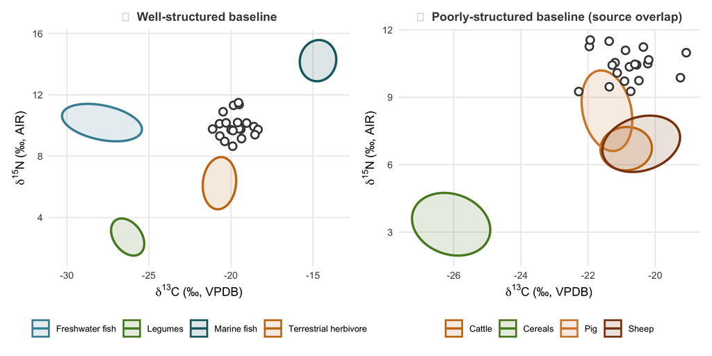

Figure 1

*Open circles = consumers; coloured ellipses = source end-members (68% confidence)*

## Four-Step Pre-Analysis Checklist

**Step 1** — Draw the δ<sup>13</sup>C–δ<sup>15</sup>N bivariate plot for all sources and consumers

**Step 2** — Check consumers fall **within** the source mixing polygon  
*(after applying trophic enrichment factors)*

**Step 3** — Identify **overlapping sources** → pool, add δ<sup>34</sup>S, or note unresolvable uncertainty

**Step 4** — Assess the **leverage** of each source — extreme values (marine fish; C<sub>4</sub> plants) will dominate model inference

**If consumers fall outside the mixing polygon:** this is a problem with the *baseline*, not the model. Return to the source inventory — do not adjust TEF priors or λ to force consumers inside.

# Trophic Enrichment Factors

## TEFs Are Not Universal Constants

Trophic enrichment factors (TEFs) vary as a function of:

- **Dietary protein quantity & quality** — protein-restricted diets → higher Δ<sup>15</sup>N (increased N recycling)
- **Physiological stress** — malnutrition, pregnancy, chronic infection → atypical Δ<sup>15</sup>N
- **Tissue type** — bone collagen ≠ muscle ≠ hair ≠ enamel carbonate
- **Species** — measurable inter-species variation in controlled feeding experiments

For *ReSources*, the routing parameter **λ** is effectively part of the enrichment framework — it must also be selected with care.

# Practical Workflow

## Six Stages Before Running *ReSources*

**Stage 1 · Preliminary Source Inventory**  
Compile all plausible protein and energy sources from zooarchaeological, archaeobotanical, and historical evidence. Assign protein/energy category.

**Stage 2 · Literature Search**  
Identify existing measurements for listed taxa. Note geographic and temporal offsets. Flag taxa requiring new primary measurement.

**Stage 3 · Specimen Selection**  
Prioritise: (a) taxa with no local measurements; (b) isotopically extreme taxa; (c) high-abundance dietary contributors; (d) high-variability taxa (fish, omnivores). Confirm contemporaneity.

**Stage 4 · Analytical Preparation & QC**  
Apply appropriate extraction protocols. Check collagen quality indicators: C:N ratio 2.9–3.6; yield > 1%; %C > 13%.

**Stage 5 · Bivariate Visualisation**  
Plot sources + consumers. Run four-step diagnostic check. Address overlap before proceeding.

**Stage 6 · *ReSources* Input Files**  
Calculate means and **biologically informed** SDs.

# Summary: Seven Key Principles

## Key Principles

1. **No baseline, no inference.** Mixing model outputs are only as reliable as the source end-members. Statistical sophistication cannot remedy inadequate inputs.
2. **The baseline must precede analysis.** Post-hoc baseline construction risks selection bias. Treat it as a prerequisite.
3. **Local and contemporaneous measurements are always preferable.** Regional δ<sup>15</sup>N variability is especially large and cannot be assumed away.
4. **Replicate to characterise variability, not just to reduce error.** Biological variability must be honestly propagated into *ReSources* source SDs.
5. **All plausible sources must be included, including rare or isotopically extreme ones.** A minor C<sub>4</sub> or marine component omitted from the baseline will corrupt the entire dietary reconstruction.
6. **Inspect source separation before running *ReSources*.** If consumers fall outside the mixing polygon, the fault is in the baseline.
7. **TEFs carry uncertainty.** Select them with the same rigour as source end-members, and report sensitivity analyses.

Module 3 complete

Proceed to **Module 4: From measured collagen to dietary source values**